# Inference on the GE with mlr3

In this notebook, we will learn how to performance inference on the *Generalization Error* (GE) using the `mlr3` ecosystem and its [`mlr3inferr`](https://github.com/mlr-org/mlr3inferr) extension. The package provides 5 methods (implemented as `mlr3::Measure`s) to construct confidence intervals for the generalization error.

To follow this tutorial, you need to install the following packages:

```r
install.packages(c(
  "mlr3",
  "mlr3inferr",
  "mlr3pipelines",
  "ggplot2"
))
```

As an example task for this tutorial, we will be using the *german credit* classification example task that comes with `mlr3`. It is a binary classification problem with 1000 observations that involves predicting whether a loan applicant is a good or bad credit risk based on 20 attributes, such as personal information and financial history.

```r
library(mlr3)
task = tsk("german_credit")
task
```

```
── <TaskClassif> (1000x21): German Credit ──────────────────────────────────────
• Target: credit_risk
• Target classes: good (positive class, 70%), bad (30%)
• Properties: twoclass
• Features (20):
  job, other_debtors, other_installment_plans, people_liable,
  personal_status_sex, property, purpose, savings, status, telephone
  • int (3): age, amount, duration
  • ord (3): installment_rate, number_credits, present_residence
```

As the learning algorithm, we will go with a simple classification tree with standard hyperparamter configurations.

```r
learner = lrn("classif.rpart")
```

```r
library(mlr3pipelines)
learner = as_learner(po("imputehist") %>>% learner)
learner$id = "log_reg"
```

In order to be able to apply probability-based measures, we instruct the `Learner` to make probability predictions:

```r
learner$predict_type = "prob"
```

## Using the Inference Methods

### Simple Holdout Method

In order to apply the simple Holdout-based CI method, we define the resampling method, where we use $90%$ of the data for training, and run the experiment:

```r
rsmp_holdout = rsmp("holdout", ratio = 0.9)
rr_holdout = resample(task, learner, rsmp_holdout)
rr_holdout
```

```
── <ResampleResult> with 1 resampling iterations ───────────────────────────────
       task_id learner_id resampling_id iteration     prediction_test warnings
 german_credit    log_reg       holdout         1 <PredictionClassif>        0
 errors
      0
```

In order to construct the confidence interval, we need to define the corresponding CI measure. It has a construction argument `measure`, which is another `mlr3::Measure`. Because this specific CI method only works with pointwise loss functions, we can e.g. not use the AUC measure:

```r
library(mlr3inferr)
msr("ci.holdout", measure = msr("classif.auc"))
```

```
Error: Assertion on 'Argument measure must be a scalar Measure with a pointwise loss function (has $obs_loss field)' failed: Must be a function, not 'NULL'.
```

Whether a measure is based on a pointwise loss function can be checked by consulting its `$obs_loss` field:

```r
msr("classif.auc")$obs_loss
```

```r
msr("classif.ce")$obs_loss
```

```
function (truth, response, ...)
{
    assert_classif(truth, response)
    as.integer(truth != response)
}
<bytecode: 0x128afb8c8>
<environment: namespace:mlr3measures>
```

Note that you can access the help page of a measure via `msr("<id>")$help()`.

**Note**

Some methods (like RMSE for regression) are strictly speaking not based on pointwise loss functions, because of the square-root after the aggregation. In this case, the measure additionally has a *trafo* defined that is applied after aggregating the pointwise losses. The confidence interval for such a loss function is obtained using the *Delta Method*.

```r
rmse = msr("regr.rmse")
rmse$trafo
```

```
$fn
function (x)  .Primitive("sqrt")

$deriv
function (x)
0.5/sqrt(x)
<bytecode: 0x12813b578>
<environment: namespace:mlr3measures>
```

Also note that currently not all `mlr3::Measure`s that are based on pointwise loss functions also implement it. If something important is missing, don’t hesitate to [open an issue in `mlr3measures`](https://github.com/mlr-org/mlr3measures/issues/new).

Below, we construct the CI measure for the classification error measure, i.e. the zero-one loss function. We set the $\alpha$ level to 0.05 (which is also the default):

```r
msr_ci_holdout = msr("ci.holdout",
  measure = msr("classif.ce"),
  alpha = 0.05
)
```

In order to construct a confidence interval, we can now simply call `$aggregate()` on the resample result and pass the CI measure: The result is a named vector with names `c("<msr-id>", "<msr-id>.lower", "<msr-id>.upper")`.

```r
ci_holdout = rr_holdout$aggregate(msr_ci_holdout)
ci_holdout
```

```
      classif.ce classif.ce.lower classif.ce.upper
       0.2800000        0.1915545        0.3684455
```

### Corrected T

To apply the *Corrected T* method, we need to use `rsmp("subsampling")` for our resample experiment. We use 90% of the data for training and conduct 25 repetitions:

```r
rsmp_subs = rsmp("subsampling",
  ratio = 0.9,
  repeats = 25
)
rsmp_subs
```

```
── <ResamplingSubsampling> : Subsampling ───────────────────────────────────────
• Iterations: 25
• Instantiated: FALSE
• Parameters: ratio=0.9, repeats=25
```

```r
rr_subs = resample(task, learner, rsmp_subs)
```

We could now again define the `msr("ci.cor_t")` and pass it to the resample result’s `$aggregate()` method. Another option is to use the `msr("ci")` measure, which auto-detects the resampling method and applies the appriopriate CI method:

```r
ci = msr("ci", measure = msr("classif.ce"))
ci_cort = rr_subs$aggregate(ci)
ci_cort
```

```
      classif.ce classif.ce.lower classif.ce.upper
       0.2480000        0.2079519        0.2880481
```

For this resampling scheme, we could also use the AUC measure, which is not based on pointwise losses:

```r
rr_subs$aggregate(msr("ci.cor_t", measure = msr("classif.auc")))
```

```
      classif.auc classif.auc.lower classif.auc.upper
        0.7441159         0.6973771         0.7908546
```

### Conservative Z

To use the *Conservative Z* method, the resample experiment needs to use the *Paired Subsampling* resampling scheme. It allows to define the repetitions of the Subsampling scheme (`repeats_in`), how often to split the data into two halves (`repeats_out`), as well as the `ratio`. The total number of resampling iterations (i.e. train-test splits) can be accessed via the `$iters` field. The default configuration of Paired Subsampling is the one suggested by Nadeau and Bengio (1999) where they introduced the method. It uses 315 iterations, which can be prohibitively expensive, especially when used in comination with hyperparameter tuning.

```r
rsmp_paired_subs = rsmp("paired_subsampling")
rsmp_paired_subs
```

```
── <ResamplingPairedSubsampling> : Paired Subsampling ──────────────────────────
• Iterations: 315
• Instantiated: FALSE
• Parameters: repeats_in=15, repeats_out=10, ratio=0.9
```

```r
rsmp_paired_subs$iters
```

```
[1] 315
```

```r
rr_paired_subs = resample(task, learner, rsmp_paired_subs)
ci_conz = rr_paired_subs$aggregate(ci)
ci_conz
```

```
      classif.ce classif.ce.lower classif.ce.upper
       0.2680000        0.2290125        0.3069875
```

Just like for the previous method, we can also use the AUC measure here:

```r
rr_paired_subs$aggregate(msr("ci.con_z", measure = msr("classif.auc")))
```

```
      classif.auc classif.auc.lower classif.auc.upper
        0.7378800         0.6869973         0.7887626
```

### Nested CV

To use the *Nested CV* method, we require the corresponding resampling scheme. It has two hyperparameters, namely the number of outer repetitions and the number of folds. The number of iterations is linear in the former, but quadratically in the latter.

```r
rsmp_ncv = rsmp("nested_cv", repeats = 20, folds = 5)
rr_ncv = resample(task, learner, rsmp_ncv)
ci_ncv = rr_ncv$aggregate(ci)
ci_ncv
```

```
      classif.ce classif.ce.lower classif.ce.upper
       0.2592675        0.2314420        0.2870930
```

### Wald CV

Finally, there is the “naive” method for the Cross-Validation:

```r
rsmp_cv = rsmp("cv", folds = 10)
rr_cv = resample(task, learner, rsmp_cv)
ci_cv = rr_cv$aggregate(ci)
ci_cv
```

```
      classif.ce classif.ce.lower classif.ce.upper
       0.2650000        0.2376464        0.2923536
```

## Comparison of Methods

In the figure below, we show all CIs side by side:

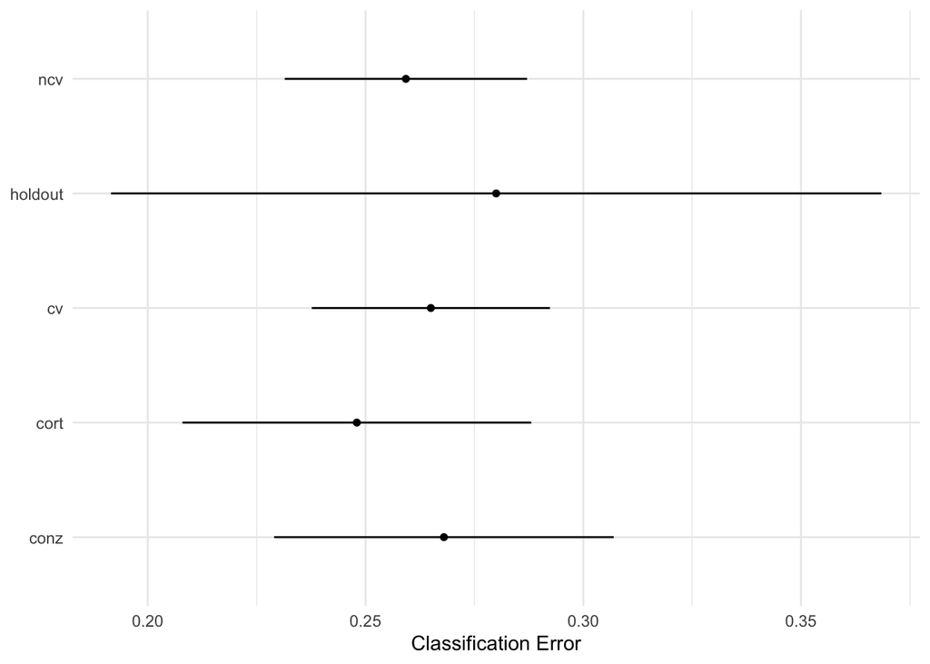

```r
library(ggplot2)
ggplot(tbl, aes(x = method, y = classif.ce)) +
  geom_pointrange(aes(ymin = classif.ce.lower, ymax = classif.ce.upper), fatten = 1.4) +
  coord_flip() +
  labs(x = NULL, y = "Classification Error") +
  theme_minimal()
```

However, the different resampling schemes had different runtime requirements:

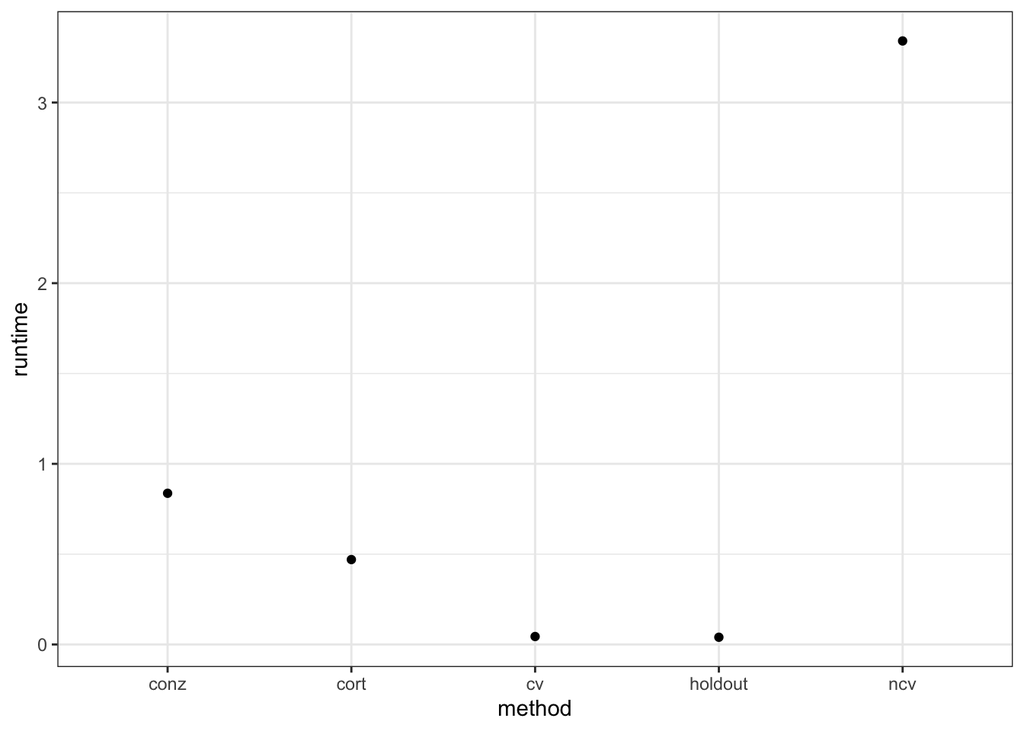

```r
ggplot(tbl, aes(x = method, y = runtime)) +
  geom_point() +
  theme_bw()
```